# Analisis Popularitas Genre Film dan Pengaruhnya terhadap Revenue pada Dataset Sakila

KHANIFAH

2026-05-13

# 1 Pendahuluan

## 1.1 Deskripsi Dataset

Dataset yang digunakan dalam laporan ini adalah dataset Sakila, yaitu database simulasi rental film yang disediakan oleh MySQL. Dataset ini berisi informasi mengenai:

- pelanggan
- transaksi rental
- pembayaran
- kategori film
- inventory
- data toko

## 1.2 Tujuan Analisis

Insight utama yang dianalisis pada laporan ini adalah:

“Bagaimana hubungan antara popularitas genre film dan kontribusinya terhadap revenue perusahaan?”

Analisis dilakukan untuk mengetahui:

1. genre film paling populer.
2. genre film paling profitable.
3. hubungan antara total rental dan total revenue.

Melalui analisis ini, perusahaan dapat memahami pola perilaku pelanggan dan menentukan strategi bisnis berbasis data.

# 2 Import Library & Database

```r
library(DBI)
library(odbc)
library(ggplot2)
```

Koneksi ke database Sakila:

```r
con <- DBI::dbConnect(odbc::odbc(),
Driver = "MySQL ODBC 8.0 ANSI Driver",
Server = "127.0.0.1",
Database = "sakila",
UID = "root",
PWD = "1strinyaWOOSEOK",
Port = 3306)
```

# 3 Analisis Genre Populer

## 3.1 Deskripsi Analisis

Analisis pertama dilakukan untuk mengetahui genre film yang paling sering disewa oleh customer. Genre dengan jumlah rental tertinggi menunjukkan preferensi utama pelanggan terhadap jenis hiburan tertentu.

```r
genre_populer <- dbGetQuery(con, "
SELECT
    c.name AS category,
    COUNT(r.rental_id) AS total_rental
FROM category c
JOIN film_category fc
    ON c.category_id = fc.category_id
JOIN inventory i
    ON fc.film_id = i.film_id
JOIN rental r
    ON i.inventory_id = r.inventory_id
GROUP BY c.name
ORDER BY total_rental DESC")

genre_populer$total_rental <- as.numeric(
  genre_populer$total_rental
)
```

## 3.2 Visualisasi Data

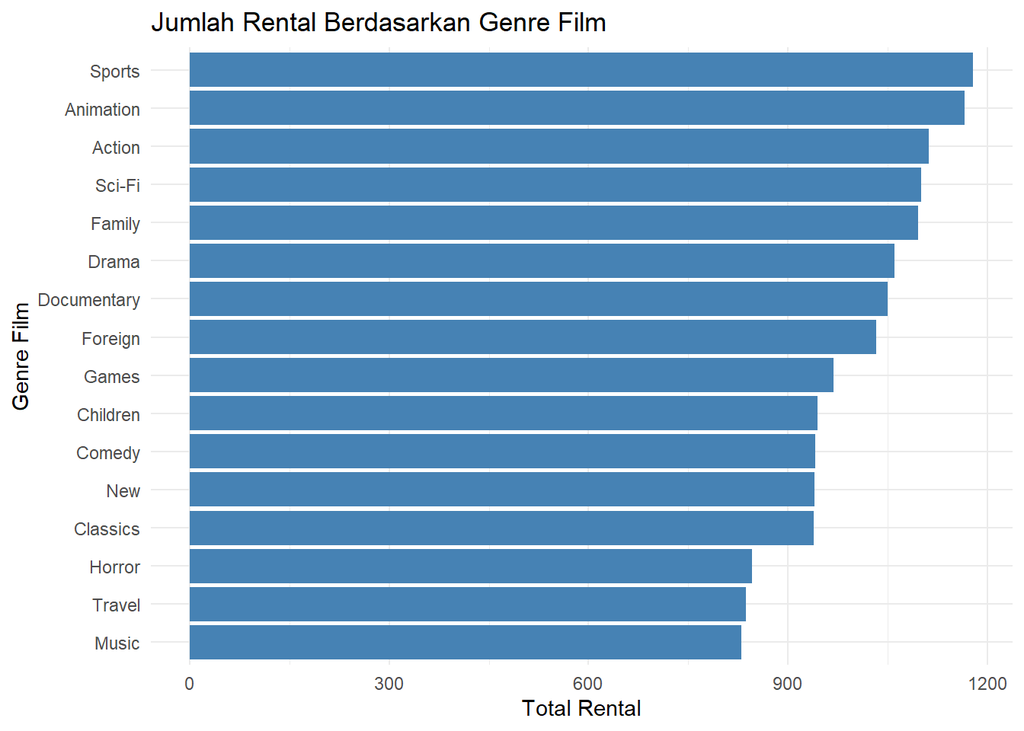

```r
ggplot(
  genre_populer,
  aes(
    x = reorder(category, total_rental),
    y = total_rental
  )
) +
  geom_bar(
    stat = "identity",
    fill = "steelblue"
  ) +
  coord_flip() +
  theme_minimal() +
  labs(
    title = "Jumlah Rental Berdasarkan Genre Film",
    x = "Genre Film",
    y = "Total Rental"
  )
```

## 3.3 Interpretasi

Hasil visualisasi menunjukkan bahwa beberapa genre memiliki jumlah rental yang jauh lebih tinggi dibanding kategori lainnya.

menempati top 3 kategori film yang paling sering disewa oleh customer.

Hal ini menunjukkan bahwa customer lebih tertarik pada film dengan hiburan ringan, cepat, dan mudah dinikmati. Dari sisi bisnis, perusahaan dapat meningkatkan inventory dan promosi pada genre dengan demand tinggi.

# 4 Analisis Genre Profitable

## 4.1 Deskripsi Analisis

Analisis kedua dilakukan untuk mengetahui kategori film yang memberikan revenue terbesar kepada perusahaan. Popularitas genre belum tentu menghasilkan profit terbesar sehingga diperlukan analisis revenue.

```r
revenue_genre<- dbGetQuery(con, "SELECT
    c.name AS category,
    SUM(p.amount) AS total_revenue
FROM category c
JOIN film_category fc
    ON c.category_id = fc.category_id
JOIN inventory i
    ON fc.film_id = i.film_id
JOIN rental r
    ON i.inventory_id = r.inventory_id
JOIN payment p
    ON r.rental_id = p.rental_id
GROUP BY c.name
ORDER BY total_revenue DESC;")

revenue_genre$total_revenue <- as.numeric(
  revenue_genre$total_revenue
)
```

## 4.2 Visualisasi Revenue per Genre

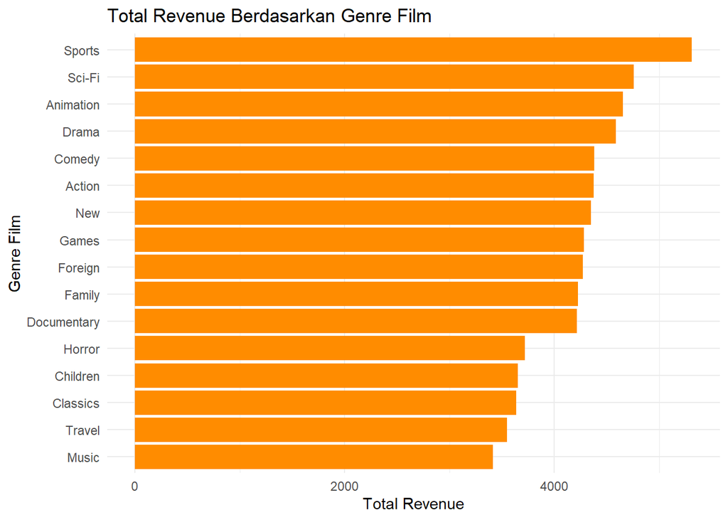

```r
ggplot(
  revenue_genre,
  aes(
    x = reorder(category, total_revenue),
    y = total_revenue
  )
) +
  geom_bar(
    stat = "identity",
    fill = "darkorange"
  ) +
  coord_flip() +
  theme_minimal() +
  labs(
    title = "Total Revenue Berdasarkan Genre Film",
    x = "Genre Film",
    y = "Total Revenue"
  )
```

## 4.3 Interpretasi

Hasil analisis menunjukkan bahwa genre dengan jumlah rental tinggi cenderung menghasilkan revenue yang besar. Namun, beberapa genre tetap menghasilkan revenue tinggi meskipun tingkat rentalnya tidak terlalu besar. Hal ini menunjukkan bahwa profitabilitas tidak hanya dipengaruhi oleh popularitas, tetapi juga perilaku transaksi customer.

# 5 Analisis Hubungan Rental dan Revenue

## 5.1 Deskripsi Analisis

Tujuan untuk melihat apakah jumlah rental memengaruhi revenue pada masing-masing genre film.

```r
data_relation <- dbGetQuery(con, "
SELECT
    c.name AS category,
    COUNT(r.rental_id) AS total_rental,
    SUM(p.amount) AS total_revenue
FROM category c
JOIN film_category fc
ON c.category_id = fc.category_id
JOIN inventory i
ON fc.film_id = i.film_id
JOIN rental r
ON i.inventory_id = r.inventory_id
JOIN payment p
ON r.rental_id = p.rental_id
GROUP BY c.name
")

data_relation$total_rental <- as.numeric(
  data_relation$total_rental
)

data_relation$total_revenue <- as.numeric(
  data_relation$total_revenue
)
```

## 5.2 Visualisasi

$$r=\frac{\sum (x_i-\bar{x})(y_i-\bar{y})}
{\sqrt{\sum (x_i-\bar{x})^2\sum (y_i-\bar{y})^2}}$$

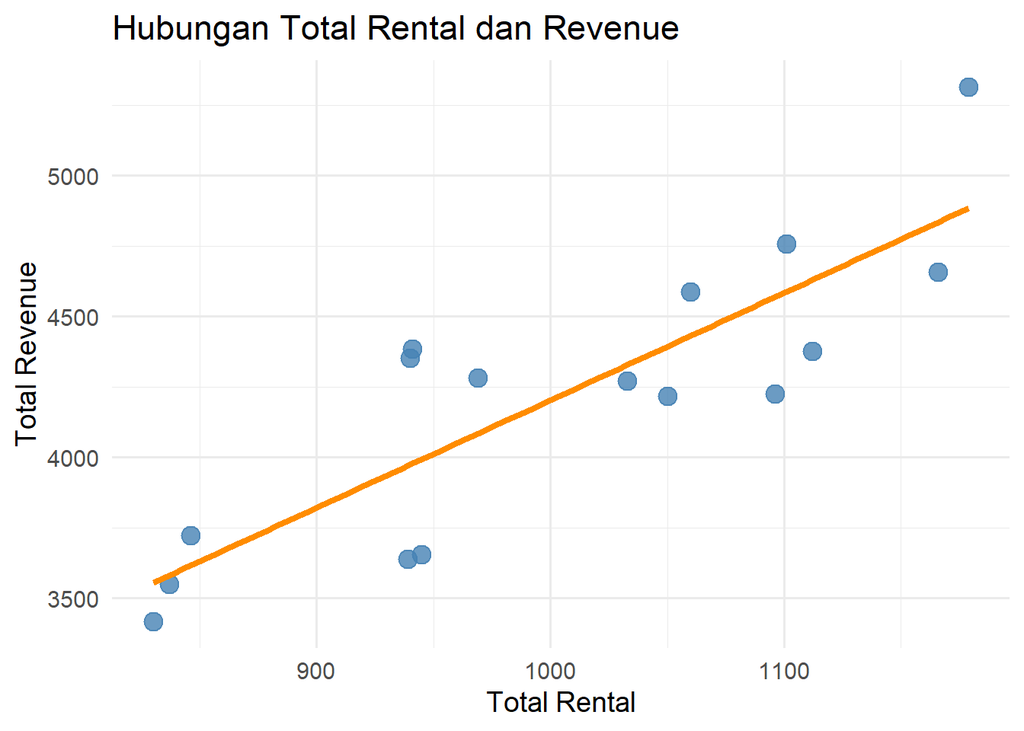

```r
ggplot(
  data_relation,
  aes(
    x = total_rental,
    y = total_revenue
  )
) +
  geom_point(
    color = "steelblue",
    size = 4,
    alpha = 0.8
  ) +
  geom_smooth(
    method = "lm",
    color = "darkorange",
    linewidth = 1.5,
    se = FALSE
  ) +
  theme_minimal(base_size = 14) +
  labs(
    title = "Hubungan Total Rental dan Revenue",
    x = "Total Rental",
    y = "Total Revenue"
  )
```

## 5.3 Analisis Korelasi

```r
cor(
  data_relation$total_rental,
  data_relation$total_revenue
)
```

```
## [1] 0.8486797
```

# 6 Kesimpulan

Berdasarkan hasil tersebut, perusahaan dapat:

1. mempertahankan inventory genre populer.
2. meningkatkan promosi pada genre profitable.
3. mengoptimalkan strategi bisnis berbasis data pelanggan.

Melalui pendekatan analisis berbasis data, perusahaan dapat mengambil keputusan bisnis yang lebih efektif dan meningkatkan profitabilitas secara keseluruhan.

```r
dbDisconnect(con)
```